# Case Study: Expanding Our Candy Brand

Nandhini Santhanam

Abstract

The lidl purchasing group intends to introduce a new candy product to increase their sales and attract new customers.This work intends to identify the characteristics of different chocolates available in the market which make them special and popular among people and thereby provide a business recommendation for the new product. In order to achieve this goal, the market research data on Candy power ranking from fivethirtyeight database is utilized.

# Introduction

```r
#Library needed for different purpose
library(plyr)
library(dplyr)
library(skimr)
library(plotly)
library(corrplot)
library(factoextra)
library(NbClust)
```

# Problem Understanding

The main aim of this work is to provide a business recommendation on the different characteristics of the candies that are more likely to become popular among the people. Using these insights, a new candy brand can be introduced to have a profit for the lidl business group. This can be achieved by converting the problem statement to a data science objective This is then followed by different analysis. This flow is explained in this document and finally a business recommendation is provided.

# Data Understanding

This section consist of the details about the data set that is used for the analysis and also the details about the quality of the data such as information about missing values.

### Overview About The Data

The input csv file consisted of 13 variables and 85 observations. The variables consists of the competitor name, 9 Boolean variable which indicates the various characteristics of the chocolate that is surveyed, percentile of sugar content in the chocolate when compared within the data set, percentile of unit price when compared with the rest of the data in the set and the overall win percentage from the total of 269,000 match ups. These can be associated with the column names that is shown below.

```r
#reading the input csv file
Candy_data <- read.csv("D:\\RstudioProjects\\candy-power-ranking\\candy-data.csv")
print(colnames(Candy_data))
```

```
##  [1] "competitorname"   "chocolate"        "fruity"
##  [4] "caramel"          "peanutyalmondy"   "nougat"
##  [7] "crispedricewafer" "hard"             "bar"
## [10] "pluribus"         "sugarpercent"     "pricepercent"
## [13] "winpercent"
```

```r
dim(Candy_data)
```

```
## [1] 85 13
```

### Quality Of The Data

When analyzing the type of the data, the winpercent,sugarpercent and pricepercent are found to be in character. It makes sense to have these quantities as numeric to do further calculation and analysis using it.The result is shown in the below code block.

```r
#checking data type of each column
apply(Candy_data,MARGIN = 2,FUN = class)
```

```
##   competitorname        chocolate           fruity          caramel
##      "character"      "character"      "character"      "character"
##   peanutyalmondy           nougat crispedricewafer             hard
##      "character"      "character"      "character"      "character"
##              bar         pluribus     sugarpercent     pricepercent
##      "character"      "character"      "character"      "character"
##       winpercent
##      "character"
```

```r
#converting the appropriate column to numeric
Candy_data$sugarpercent <- as.numeric(Candy_data$sugarpercent)
Candy_data$pricepercent <- as.numeric(Candy_data$pricepercent)
Candy_data$winpercent <- as.numeric(Candy_data$winpercent)

#Candy_data[2:13] <- as.numeric(Candy_data[2:13])
#check if the data type is updated

print("After the updation")
```

```
## [1] "After the updation"
```

```r
apply(Candy_data[11:13],MARGIN = 2,FUN = class)
```

```
## sugarpercent pricepercent   winpercent
##    "numeric"    "numeric"    "numeric"
```

Skim function from package skimr allows you to comprehensively check the quality of the data such as information about missing values. The data that is used for the analysis of this work does not have any missing value which is shown by the n_missing attribute for every column of the original data frame.

```r
#Check for missing values, statistical value like mean,median,sd for numerical quantities.
skimmed_Info <- skim(Candy_data)

#check if any column has missing values

which(skimmed_Info$n_missing > 0)
```

```
## integer(0)
```

We can also skim through the numeric features such as **winpercent , pricepercent, sugarpercent**. This function shows the statistical values such as mean,median,quantiles and also its histogram in the table below.

```r
# skimming of WinPercent
skim(Candy_data) %>%
  dplyr::filter(skim_variable == "winpercent")
```

Data summary

| Name | Candy_data |
| --- | --- |
| Number of rows | 85 |
| Number of columns | 13 |
| _______________________ |  |
| Column type frequency: |  |
| numeric | 1 |
| ________________________ |  |
| Group variables | None |

**Variable type: numeric**

| skim_variable | n_missing | complete_rate | mean | sd | p0 | p25 | p50 | p75 | p100 | hist |
| --- | --- | --- | --- | --- | --- | --- | --- | --- | --- | --- |
| winpercent | 0 | 1 | 50.32 | 14.71 | 22.45 | 39.14 | 47.83 | 59.86 | 84.18 | ▃▇▆▅▂ |

```r
# skimming of pricepercent
skim(Candy_data) %>%
  dplyr::filter(skim_variable == "pricepercent")
```

Data summary

| Name | Candy_data |
| --- | --- |
| Number of rows | 85 |
| Number of columns | 13 |
| _______________________ |  |
| Column type frequency: |  |
| numeric | 1 |
| ________________________ |  |
| Group variables | None |

**Variable type: numeric**

| skim_variable | n_missing | complete_rate | mean | sd | p0 | p25 | p50 | p75 | p100 | hist |
| --- | --- | --- | --- | --- | --- | --- | --- | --- | --- | --- |
| pricepercent | 0 | 1 | 0.47 | 0.29 | 0.01 | 0.26 | 0.46 | 0.65 | 0.98 | ▇▇▇▇▆ |

```r
# skimming of sugarpercent
skim(Candy_data) %>%  dplyr::filter(skim_variable == "sugarpercent")
```

Data summary

| Name | Candy_data |
| --- | --- |
| Number of rows | 85 |
| Number of columns | 13 |
| _______________________ |  |
| Column type frequency: |  |
| numeric | 1 |
| ________________________ |  |
| Group variables | None |

**Variable type: numeric**

| skim_variable | n_missing | complete_rate | mean | sd | p0 | p25 | p50 | p75 | p100 | hist |
| --- | --- | --- | --- | --- | --- | --- | --- | --- | --- | --- |
| sugarpercent | 0 | 1 | 0.48 | 0.28 | 0.01 | 0.22 | 0.46 | 0.73 | 0.99 | ▇▇▇▇▆ |

# Objective - Data Science Problem

In order to achieve the business recommendation, data driven analytic approach should be followed. Using the data set provided, beneficial insights must be derived. In order to achieve the same, the following tasks are carried out and a final conclusion in formulated based on its results.

1. Plotting of histogram of the different variables and arrive at a statistical inference about its distribution.
2. Analyse the correlation between different variables in the data set with that of the win percentage.
3. Perform exploratory analysis to identify the different behavior and pattern in the data.
4. Perform a cluster analysis to identify if there are any clusters present in the data set.

# Exploratory Analysis

## Histogram Of The Variables

In the data set there are 9 quality variables which has values either 1 or 0. 1 indicates the corresponding characteristics to be present in the candy and 0 indicates the corresponding characteristics is not present in the candy. In order to find the distribution of these variables, a histogram is plotted for these variables using Plotly package. The code below shows the same.

```r
Candy_data[,c(2:10)]<-apply(Candy_data[2:10],MARGIN = 2,FUN = as.factor)


plotList = list()
plotListNames = colnames(Candy_data[2:10])
```

```r
#function to plot the histograms of different variables
Stackedhistogram <- function(plotListNames ,Candy_data)
{
  plotList = list()
for(i in 1:length(plotListNames))
{
thisName = plotListNames[i]
plotList[[thisName]] <-plotly_build( plot_ly(x=~Candy_data[,i],type="histogram", name = thisName) %>%  layout(title="Histogram of different variables",xaxis = list(
title = plotListNames[i]),yaxis = list(title = "Count")) )

}
return(plotList)
}

plotList<-Stackedhistogram(plotListNames,Candy_data[2:10])


subplot(plotList,nrows = 3,shareY = T)
```

[interactive chart not shown]

## Correlation Analysis

Correlation analysis will provide more insights to determine what type of characteristics has good correlation with that of the other features. A correlation matrix is formed between all the variables leaving out the competitor name.

```r
Candy_data[,c(2:10)]<-apply(Candy_data[2:10],MARGIN = 2,FUN = as.numeric)
M <- cor(x = Candy_data[2:13])
```

In order to determine the statistical significance of the correlation co efficient, p value is calculated for the correlation matrix. This is calculated by the function which is mentioned in the below code block.

```r
#function to calculate p value of correlation matrix

cor.mtest <- function(mat, ...) {
    mat <- as.matrix(mat)
    n <- ncol(mat)
    p.mat<- matrix(NA, n, n)
    diag(p.mat) <- 0
    for (i in 1:(n - 1)) {
        for (j in (i + 1):n) {
            tmp <- cor.test(mat[, i], mat[, j], ...)
            p.mat[i, j] <- p.mat[j, i] <- tmp$p.value
        }
    }
  colnames(p.mat) <- rownames(p.mat) <- colnames(mat)
  p.mat
}


# matrix of the p-value of the correlation
p.mat <- cor.mtest(Candy_data[2:13])
```

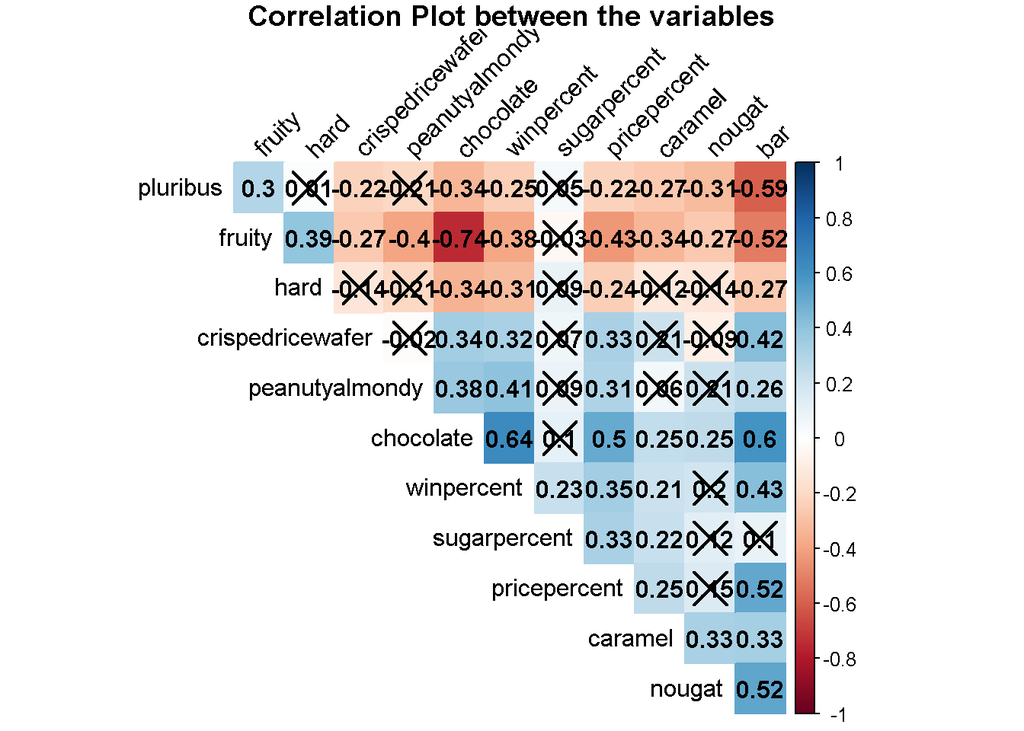

```r
corrplot(M, method="color",
         type="upper", order="hclust",
         addCoef.col = "black", # Add coefficient of correlation
         tl.col="black", tl.srt=45, #Text label color and rotation
         # Combine with significance
         p.mat = p.mat, sig.level = 0.05,
         # hide correlation coefficient on the principal diagonal
         diag=F,title = "Correlation Plot between the variables",
           mar=c(0,0,1,0)
         )
```

- Chocolate and fruity characteristics have high negative correlation indicating that there is a very less chance that the candy has both chocolate and fruit in it.
- There is only one such data point in the data set and it its **Tootsie Pop**.

|  | competitorname | chocolate | fruity | sugarpercent | pricepercent | winpercent |
| --- | --- | --- | --- | --- | --- | --- |
| 75 | Tootsie Pop | 1 | 1 | 0.604 | 0.325 | 48.98265 |

We can derive the correlation of the other input variables with respect to the winpercentage variable alone.

```r
print(cor(Candy_data[2:12],Candy_data$winpercent))
```

```
##                        [,1]
## chocolate         0.6365167
## fruity           -0.3809381
## caramel           0.2134163
## peanutyalmondy    0.4061922
## nougat            0.1993753
## crispedricewafer  0.3246797
## hard             -0.3103816
## bar               0.4299293
## pluribus         -0.2474479
## sugarpercent      0.2291507
## pricepercent      0.3453254
```

- The above result indicates that the **chocolate** has high positive correlation with that of the win percent indicating the high popularity with customers.
- Even bar, peanut almondy, crispedricewafer has positive correlation with the win percent. But the number of observations that have a value of one for these characteristics are less in the total observations. This was also observed in the histogram plot as well.
- The **fruity** and **pluribus** has negative correlation with that of win percent indicating that these are not popular among customers.
- The hard type also has a negative correlation with the win percent but the number of observation with one value in hard type is less when compared to total number of observation.

## Derived Features

1. **Type** : A new feature is calculated to find out the unique combinations of different characteristics that are present in the candies. In order to find it, the binary combinations of 1 and 0 is converted to a decimal value. This method gives a unique value for every combination.

```r
#Type id to indicate the unique combinations [Conversion of binary to decimal approach]
Candy_data$Type <- (Candy_data$chocolate* 1) + (Candy_data$fruity* 2) +  (Candy_data$caramel * 4) + (Candy_data$peanutyalmondy* 8) + (Candy_data$nougat* 16) + (Candy_data$crispedricewafer* 32) + (Candy_data$hard* 64) + (Candy_data$bar* 128) + (Candy_data$pluribus* 256)

summary(Candy_data$Type)
```

```
##    Min. 1st Qu.  Median    Mean 3rd Qu.    Max.
##     0.0   129.0   256.0   182.7   258.0   322.0
```

```r
#length of unique combinations
length(unique(Candy_data$Type))
```

```
## [1] 29
```

```r
#frequency of each type of combinations

Unique_Combinations <-plyr::count(Candy_data$Type)

print(Unique_Combinations[c(order(Unique_Combinations$freq,decreasing = T)),])
```

```
##      x freq
## 22 258   19
## 29 322    7
## 21 257    6
## 3    2    5
## 7   66    5
## 10 129    4
## 6    9    3
## 12 137    3
## 17 161    3
## 20 256    3
## 26 265    3
## 1    0    2
## 13 145    2
## 14 149    2
## 16 157    2
## 18 165    2
## 24 261    2
## 2    1    1
## 4    4    1
## 5    6    1
## 8   67    1
## 9   68    1
## 11 133    1
## 15 152    1
## 19 173    1
## 23 260    1
## 25 264    1
## 27 289    1
## 28 320    1
```

```r
#total number of qualitative characteristics available for a competitor.
Candy_data$NoOfQualityFeatures <- apply(Candy_data[2:10],MARGIN = 1,FUN = sum)

#summary

summary(Candy_data$NoOfQualityFeatures)
```

```
##    Min. 1st Qu.  Median    Mean 3rd Qu.    Max.
##   0.000   2.000   2.000   2.318   3.000   5.000
```

```r
#histogram for NoOfQualityFeatures
plot_ly(x=~Candy_data[,15],type="histogram") %>%  layout(title="Histogram of the Number of quality features",xaxis = list(
title = "NoOfQualityFeatures"),yaxis = list(title = "Count"))
```

[interactive chart not shown]

- The histogram plot shows that the most of the candies have either 2 or 3 characteristics.
- There are two candies which does not have any of the characteristics that is listed in the data set and they are “one dime” and “one quarter”. These two have the same sugar percent also. So the winpercent for these two candies solely depends on the pricepercent value. obviously the type variable is also 0 for both the candies.This is indicated by the correlation between them to be 1.

```r
cor(Candy_data$pricepercent[which(Candy_data$NoOfQualityFeatures==0)],Candy_data$winpercent[which(Candy_data$NoOfQualityFeatures==0)])
```

```
## [1] 1
```

## Observations From Data

1. Top ten winner candies based on its win percentile

```r
Top_10_Candy<-head(Candy_data[c(order(Candy_data$winpercent,decreasing = T)),],10)
Top_10_Candy
```

|  | competitorname | chocolate | fruity | caramel | peanutyalmondy | nougat | crispedricewafer | hard | bar | pluribus | sugarpercent | pricepercent | winpercent | Type | NoOfQualityFeatures |
| --- | --- | --- | --- | --- | --- | --- | --- | --- | --- | --- | --- | --- | --- | --- | --- |
| 53 | ReeseÕs Peanut Butter cup | 1 | 0 | 0 | 1 | 0 | 0 | 0 | 0 | 0 | 0.720 | 0.651 | 84.18029 | 9 | 2 |
| 52 | ReeseÕs Miniatures | 1 | 0 | 0 | 1 | 0 | 0 | 0 | 0 | 0 | 0.034 | 0.279 | 81.86626 | 9 | 2 |
| 80 | Twix | 1 | 0 | 1 | 0 | 0 | 1 | 0 | 1 | 0 | 0.546 | 0.906 | 81.64291 | 165 | 4 |
| 29 | Kit Kat | 1 | 0 | 0 | 0 | 0 | 1 | 0 | 1 | 0 | 0.313 | 0.511 | 76.76860 | 161 | 3 |
| 65 | Snickers | 1 | 0 | 1 | 1 | 1 | 0 | 0 | 1 | 0 | 0.546 | 0.651 | 76.67378 | 157 | 5 |
| 54 | ReeseÕs pieces | 1 | 0 | 0 | 1 | 0 | 0 | 0 | 0 | 1 | 0.406 | 0.651 | 73.43499 | 265 | 3 |
| 37 | Milky Way | 1 | 0 | 1 | 0 | 1 | 0 | 0 | 1 | 0 | 0.604 | 0.651 | 73.09956 | 149 | 4 |
| 55 | ReeseÕs stuffed with pieces | 1 | 0 | 0 | 1 | 0 | 0 | 0 | 0 | 0 | 0.988 | 0.651 | 72.88790 | 9 | 2 |
| 33 | Peanut butter M&MÕs | 1 | 0 | 0 | 1 | 0 | 0 | 0 | 0 | 1 | 0.825 | 0.651 | 71.46505 | 265 | 3 |
| 43 | Nestle Butterfinger | 1 | 0 | 0 | 1 | 0 | 0 | 0 | 1 | 0 | 0.604 | 0.767 | 70.73564 | 137 | 3 |

- All the top 10 candies are having the feature **chocolate** as 1 and **fruity** as 0. The candies that are chocolaty and not fruity are having high winpercentage among the customers.
- The **candy type 9** (Chocolate - 1 and PeanutAlmondy - 1)are present 3 times in the data set and all three competitors are present in the **top 10 candies**. Upon analyzing the correlation of sugarpercent and pricepercent of this type of candy with that of win percent shows that they are having negative correlation of -0.5 and -0.3. With only three data points its tough to conclude which affects the winpercent. But the type 9 which is the candies from Ressea is popular.

```r
#analysis on candy type 9
Candy_type_9 <- Candy_data[which(Candy_data$Type==9),c(1,11:14)]
head(Candy_type_9)
```

|  | competitorname | sugarpercent | pricepercent | winpercent | Type |
| --- | --- | --- | --- | --- | --- |
| 52 | ReeseÕs Miniatures | 0.034 | 0.279 | 81.86626 | 9 |
| 53 | ReeseÕs Peanut Butter cup | 0.720 | 0.651 | 84.18029 | 9 |
| 55 | ReeseÕs stuffed with pieces | 0.988 | 0.651 | 72.88790 | 9 |

```r
cor(Candy_type_9[2:3],Candy_type_9$winpercent)
```

```
##                    [,1]
## sugarpercent -0.5681202
## pricepercent -0.3225215
```

- In total there are only 14 candies that have the **peanutalmondy** feature as 1 in the total of 85 observations. But in that, **7** of them are in the top 10 candy list. This indicates that there is 50% chance that a candy having peanutalmondy to be more popular with the customer.

```r
#total number of candies having peanut almondy in the top 10 candies
length(which(Top_10_Candy$peanutyalmondy==1))
```

```
## [1] 7
```

```r
#total number of candies having peanut almondy in the whole data set
length(which(Candy_data$peanutyalmondy==1))
```

```
## [1] 14
```

- All the top 10 candies have **more than 1** characteristics which can be seen from the “NoOfQualityFeatures” variable shown below.

```r
length(which(Top_10_Candy$NoOfQualityFeatures > 1))
```

```
## [1] 10
```

- When analyzing the pricepercent feature of the top 10 candies, 6 candies were having a price percentile value **0.651** which is composed of different characteristics (different Type value).
- There is a candy **Reeseas Miniatures** in the top ten candies which is very cheap.

  |  | competitorname | sugarpercent | pricepercent | winpercent | Type |
  | --- | --- | --- | --- | --- | --- |
  | 52 | ReeseÃ•s Miniatures | 0.034 | 0.279 | 81.86626 | 9 |

- There is a candy **Twix** in the top ten candies that is very costly and also popular.

|  | competitorname | sugarpercent | pricepercent | winpercent | Type |
| --- | --- | --- | --- | --- | --- |
| 80 | Twix | 0.546 | 0.906 | 81.64291 | 165 |

Before starting with if there is a clusters present in the data, When there is a multicollinearity in the variables, it is better to do a dimensionality reduction and then perform the cluster analysis. The below code block shows the reduction of the input variable into two principal components.

```r
#reduction into two principal components
pca_data<-prcomp(Candy_data[,c(2:13)],rank. = 2,center = T,scale. = T)
# retriving the principal component values as a data frame
pca_data <- as.data.frame(pca_data$x)
```

```r
#fitting Kmeans Cluster
fitKmeans<-kmeans(pca_data,centers = 3)

#concatenating the cluster ID with the PCA_data frame
pca_data$clusters <- fitKmeans$cluster

Candy_data <- cbind(Candy_data,pca_data)
```

```r
#plotting the principal components and coloured by the cluster numbers
plot_ly(data = Candy_data, x = ~PC2, y = ~PC1, color = ~as.factor(pca_data$clusters),type = "scatter",mode="markers",colors="Set1")%>%  layout(title="Scatter plot between PC's and coloured by Cluster ID",xaxis = list(
title = "Principal Component 2"),yaxis = list(title = "Principal Component 1"))
```

[interactive chart not shown]

In order to analyse the characteristics of the three clusters, the below data frame is created.

```r
cluster_Data <- Candy_data %>%
                group_by(clusters)%>%
                summarise(count=length(clusters),Chocolate=length(which(chocolate==1)),fruity=length(which(fruity==1)),caramel=length(which(caramel==1)),peanutyalmondy=length(which(peanutyalmondy==1)),nougat=length(which(nougat==1)),crispedricewafer=length(which(crispedricewafer==1)),hard=length(which(hard==1)),bar=length(which(bar==1)),pluribus=length(which(pluribus==1)),AvgSugar =mean(sugarpercent),AvgPrice = mean(pricepercent),Avgwin =mean(winpercent))

cluster_Data
```

| clusters | count | Chocolate | fruity | caramel | peanutyalmondy | nougat | crispedricewafer | hard | bar | pluribus | AvgSugar | AvgPrice | Avgwin |
| --- | --- | --- | --- | --- | --- | --- | --- | --- | --- | --- | --- | --- | --- |
| 1 | 17 | 17 | 0 | 2 | 6 | 0 | 1 | 0 | 2 | 11 | 0.4871176 | 0.5700588 | 60.40989 |
| 2 | 19 | 18 | 0 | 8 | 7 | 7 | 6 | 0 | 19 | 0 | 0.5423158 | 0.7400000 | 62.61686 |
| 3 | 49 | 2 | 38 | 4 | 1 | 0 | 0 | 15 | 0 | 33 | 0.4510204 | 0.3286531 | 42.04564 |

```r
#total count of caramel
length(which(Candy_data$caramel==1))
```

```
## [1] 14
```

```r
#total count of chocolate and caramel
length(which(Candy_data$caramel==1 & Candy_data$chocolate ==1))
```

```
## [1] 10
```

```r
#clusters of Candies with chocolate and caramel
(Candy_data$clusters[which(Candy_data$caramel==1 & Candy_data$chocolate ==1)])
```

```
##  [1] 2 2 1 2 2 2 1 2 2 2
```

```r
#clusters of Candies without chocolate and with caramel
(Candy_data$clusters[which(Candy_data$caramel==1 & Candy_data$chocolate !=1)])
```

```
## [1] 3 3 3 3
```

- There is no much difference between these clusters when its comes to Average Sugar percent in it.
- Candies in **Cluster 2** are the **Costliest** and the candies in **Cluster 3** are the **Cheapest**.
- Cluster 2 has the **highest win percentage(62.6%)** and the **Cluster 1** has the **second highest win percentage(60.4%)** and **Cluster 3** is the **least**.

# Business Recommendation From The Analysis

Based on the exploratory and cluster analysis, the following business recommendation can be useful in achieving the popularity for newly introducing candy brand.

- Candies that are chocolaty are more popular with the customers.
- Based on data, if the caramel comes with the chocolate flavor rather than alone is famous with customer
- Candies having Peanutalmondy is having 50% chance to end up in top 10 candies in the market.
- Candies that fall in the Cluster 1 and Cluster 2 are having almost similar average win percentage of around 61%.
- But the Candies that fall in Cluster 2 has high average price percent when compared to candies that fall in Cluster 1. Even though the candies in Cluster 2 is costlier, they are having high win percentage.This (Candies of Cluster 2) can be little more economically beneficial to the lidl business group when compared to the Candies of Cluster 1 if their manufacturing cost is similar.
- Introducing candies with characteristics that of the candies in Cluster 1 and 2 would be the best for Lidl business group.
  - Candies with a layer of **Chocolate** and **Caramel**
  - Candies with a **PeanutAlmondy** in it.
  - Candies with **Nougat** in it.
  - Candies should **not be hard**
  - Candies should come in **Bar** form.

# Conclusion

1. Thus the objective of the work to provide a business recommendation about the characteristics of the candy that should be introduced by the lidl group to become popular among customers are achieved.
2. The solution is achieved by first setting the objective in data science perspective and further dividing into sub tasks.
3. The results from the various sub tasks were useful in arriving at the business recommendation.